# residential_displacement

##### Vehicle ownership

It’s difficult to interpret because of the large moes and the multiple dimensions. One major conclusions could be:

- Fewer 2-vehicle households were displaced in 2021 (during/after COVID)
- Shares of displacement among 0-vehicle households and 1-vehicle households was similar over time

**This is different from general movers sample where 2-vehicle households were close to the share of 1-vehicle households. Among displaced movers, there are similar shares of 0-vehicle households and 2-vehicle households.**

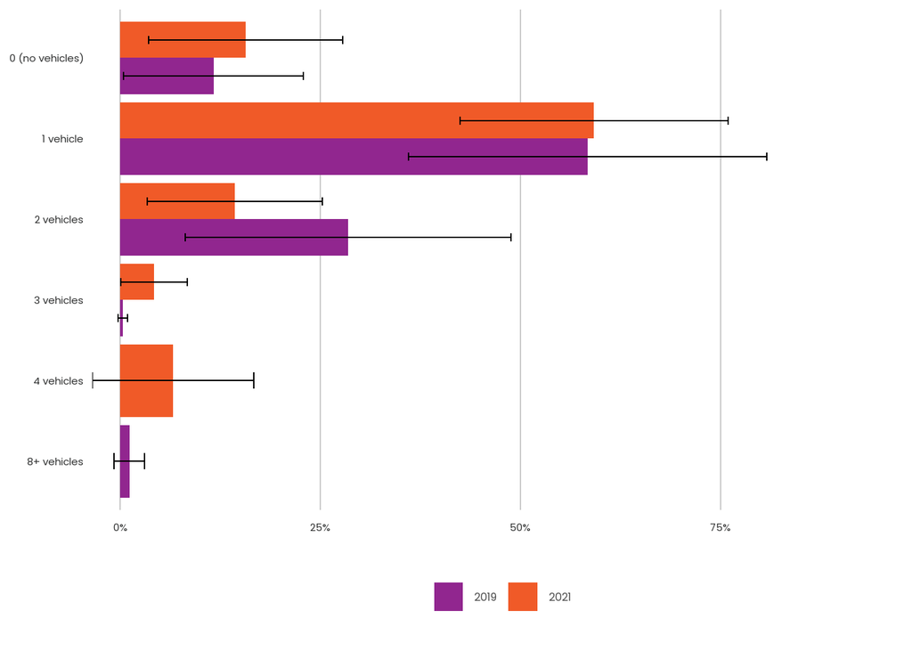

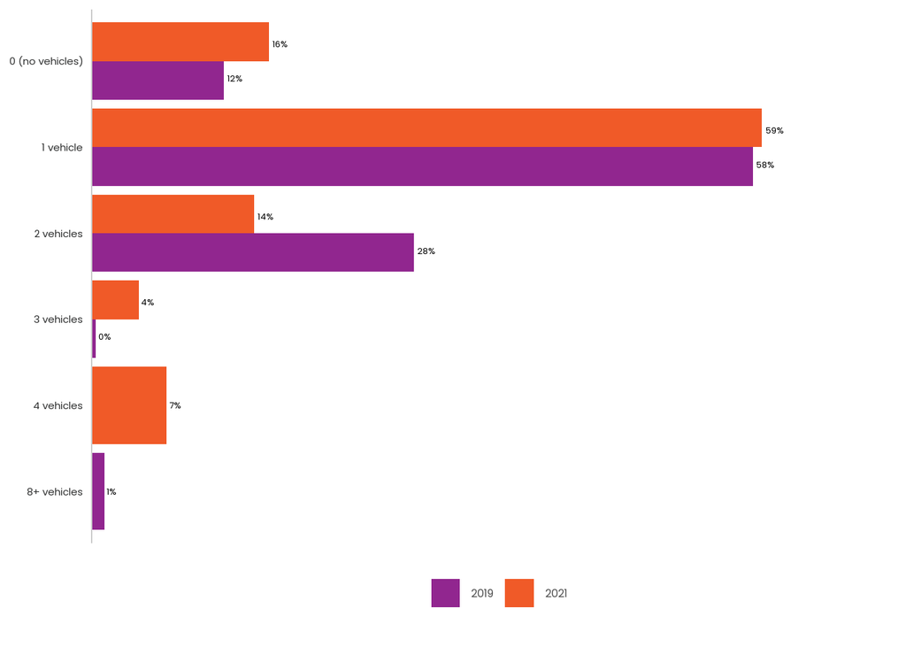

###### Simplified vehicle ownership

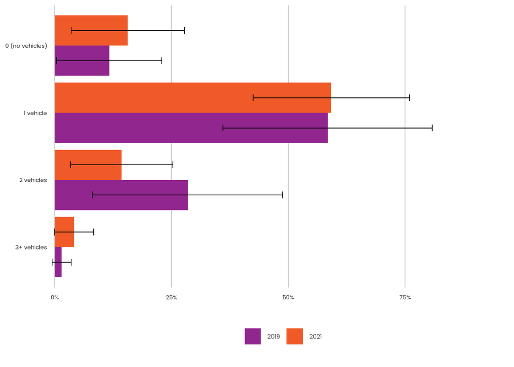

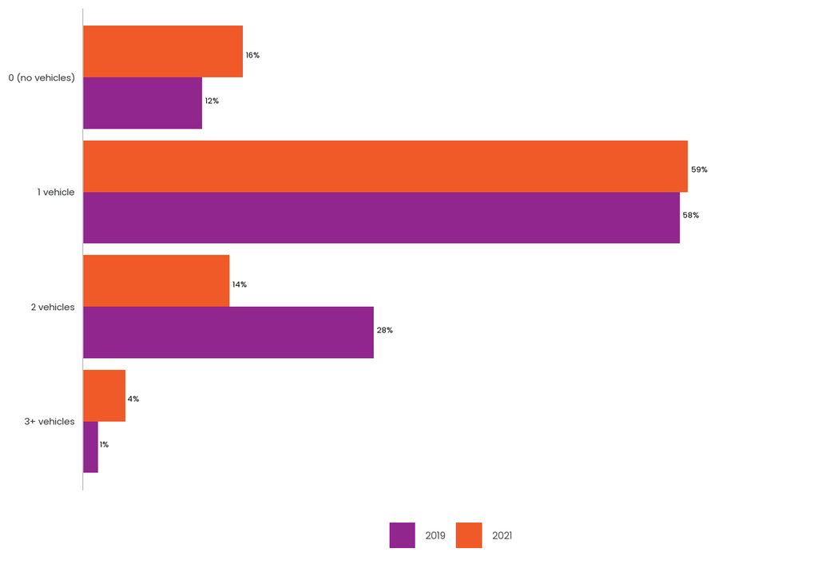

#### Overlapping time periods

Showing displacement by time period. this part is a little tricky; i think I need someone to check me.

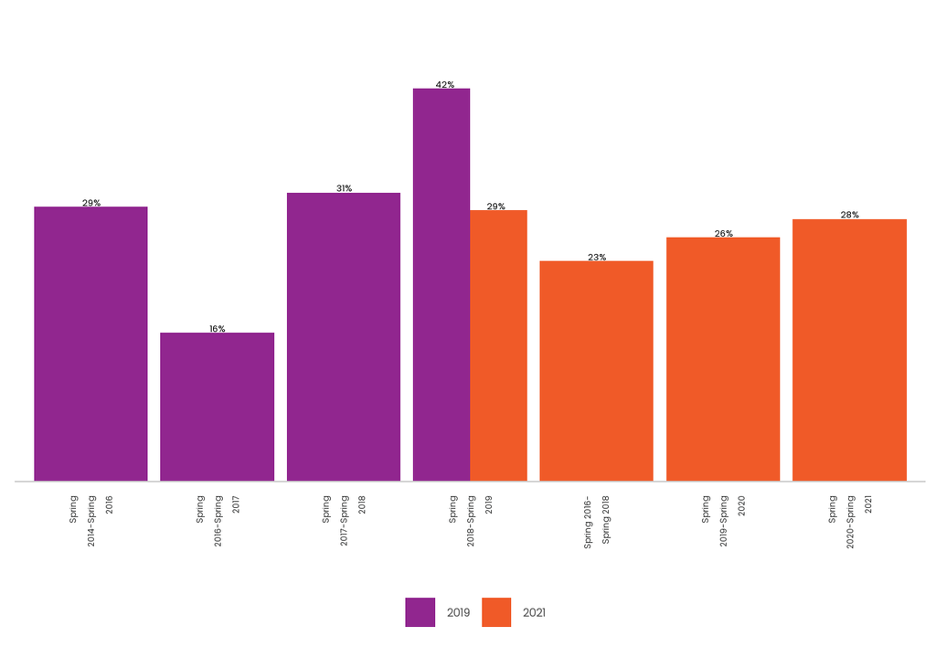

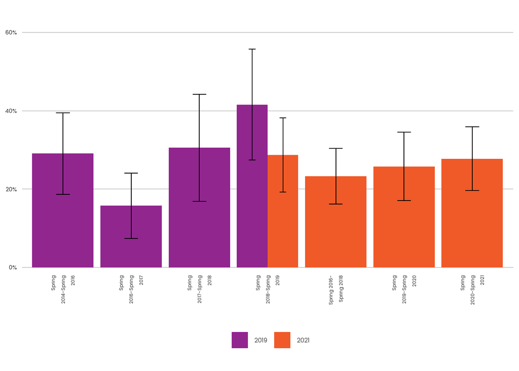

### Reasons for moving

Why did you move to current residence

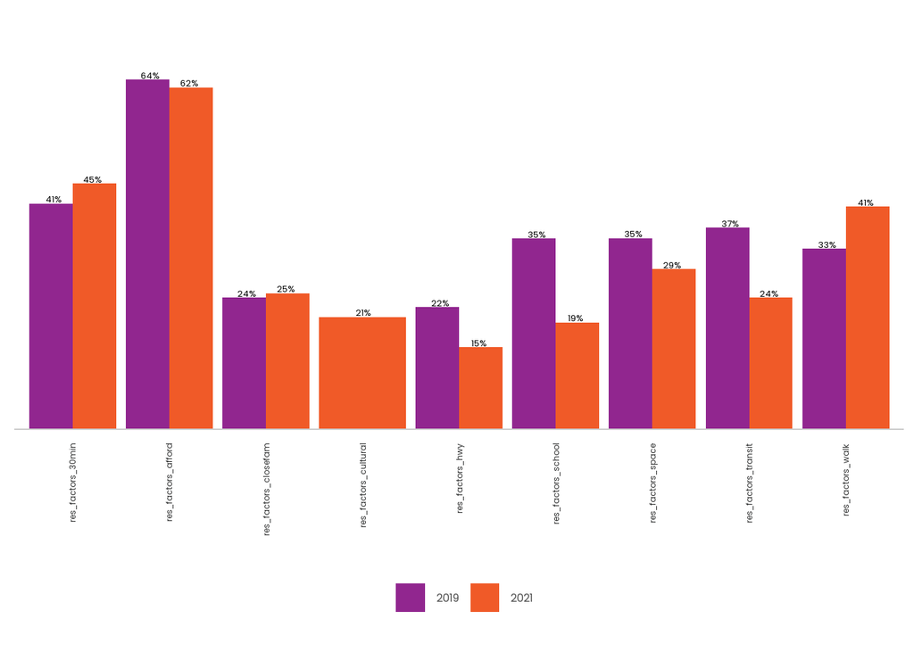

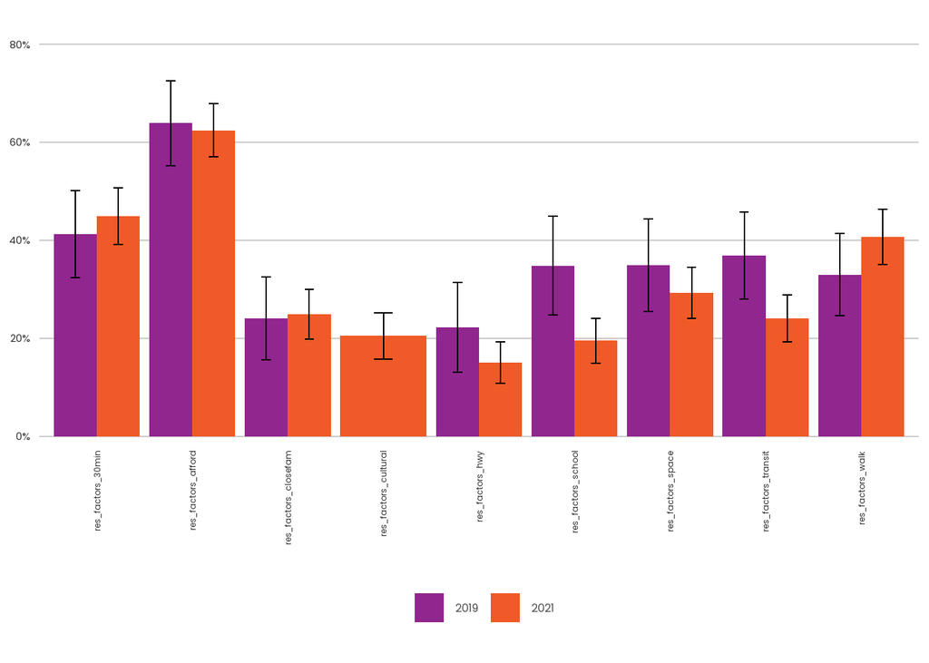

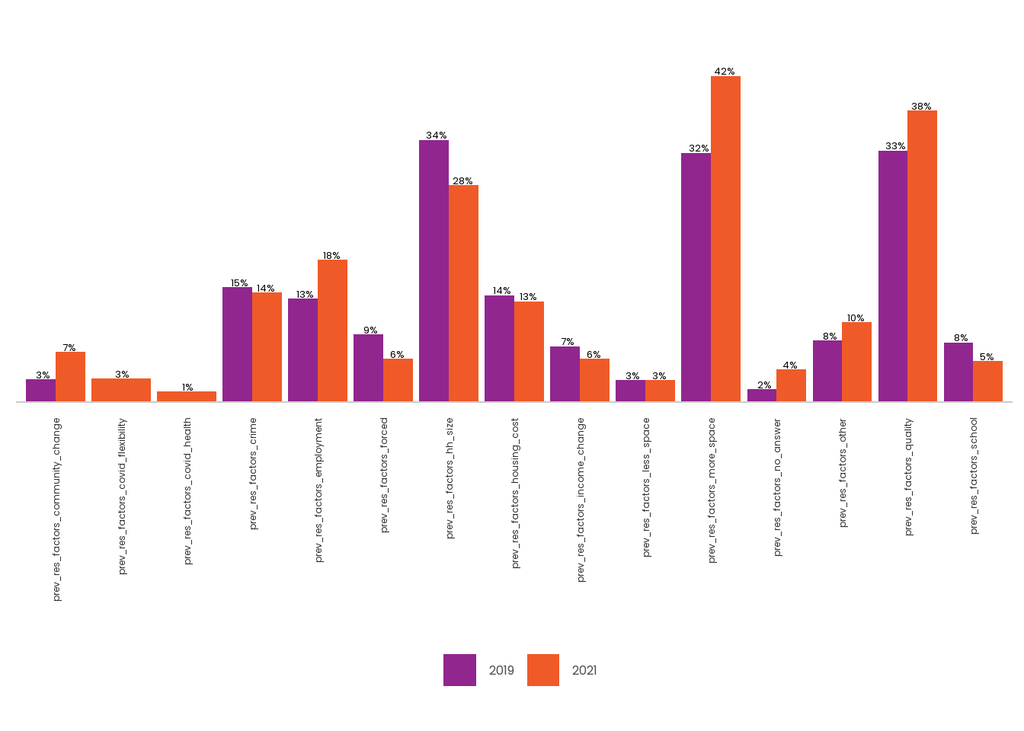

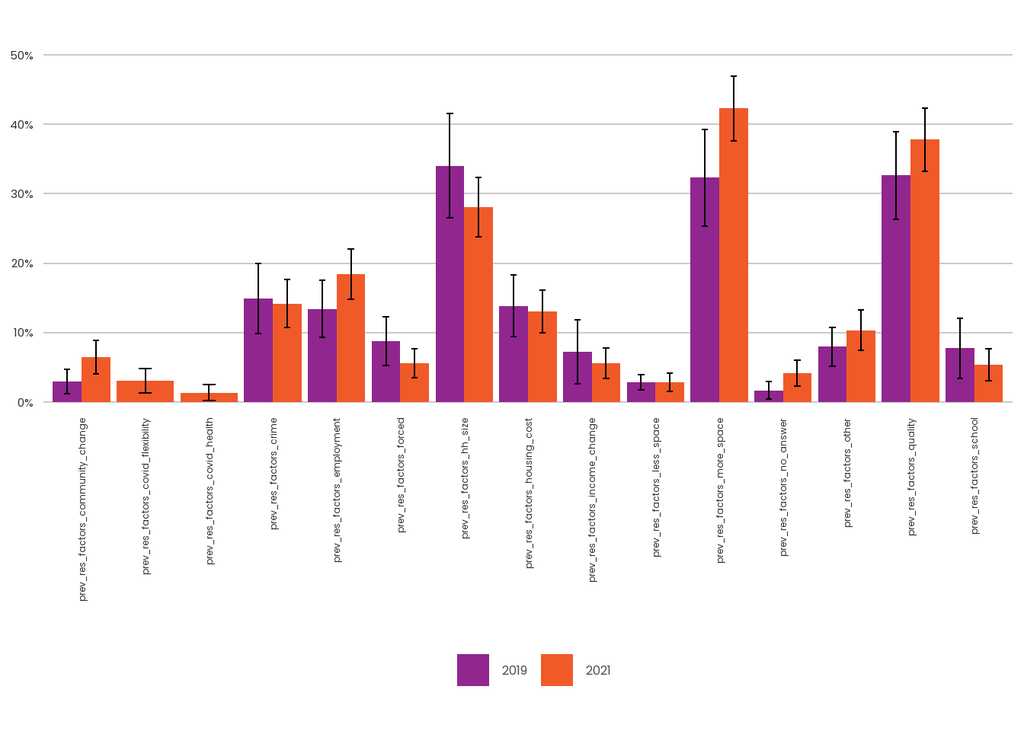

redefining

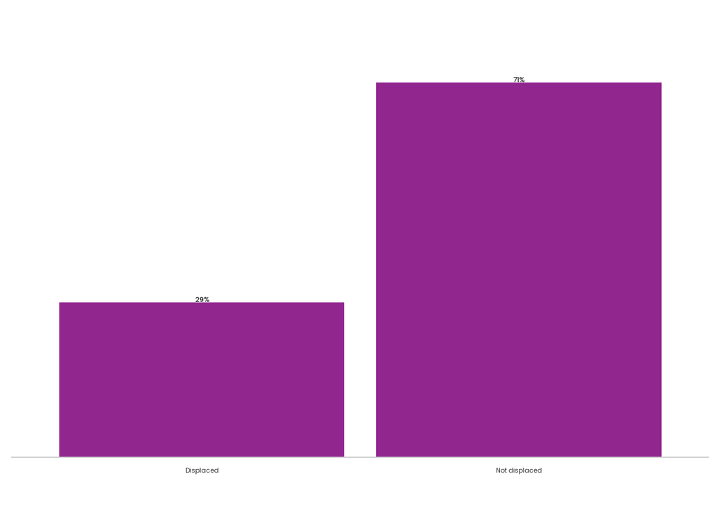

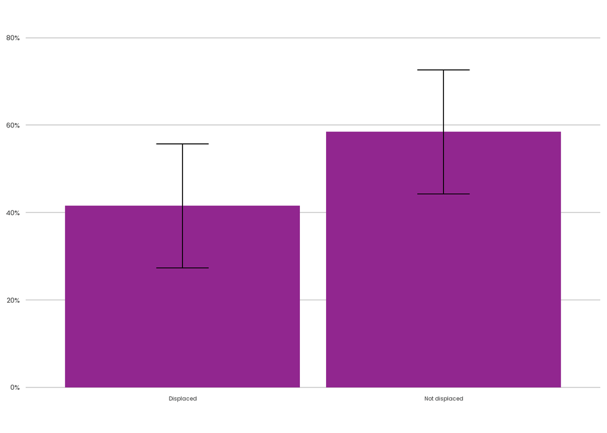

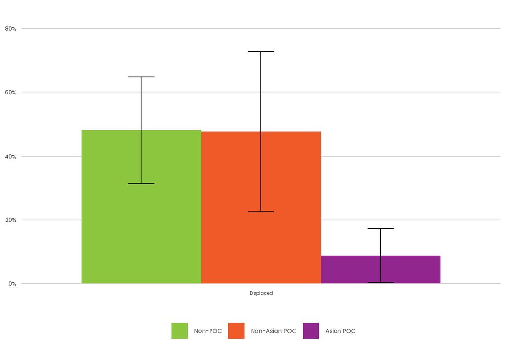

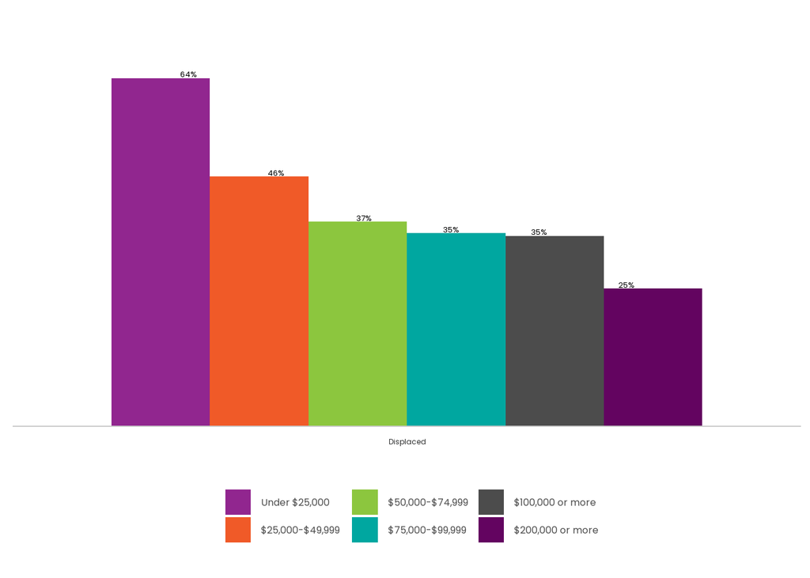

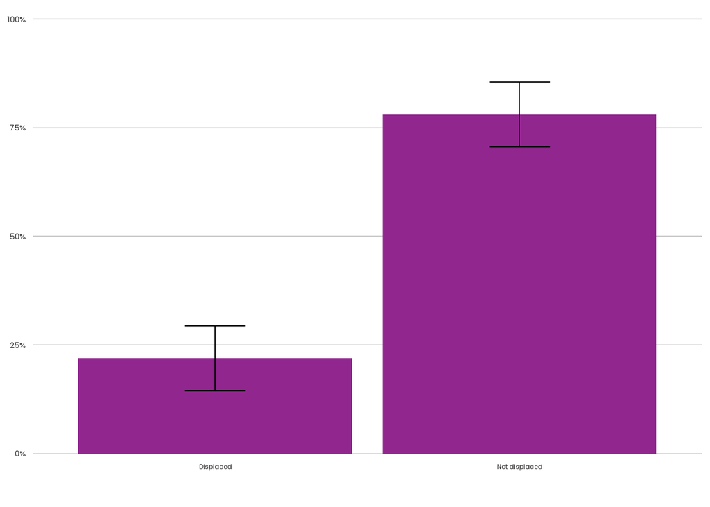

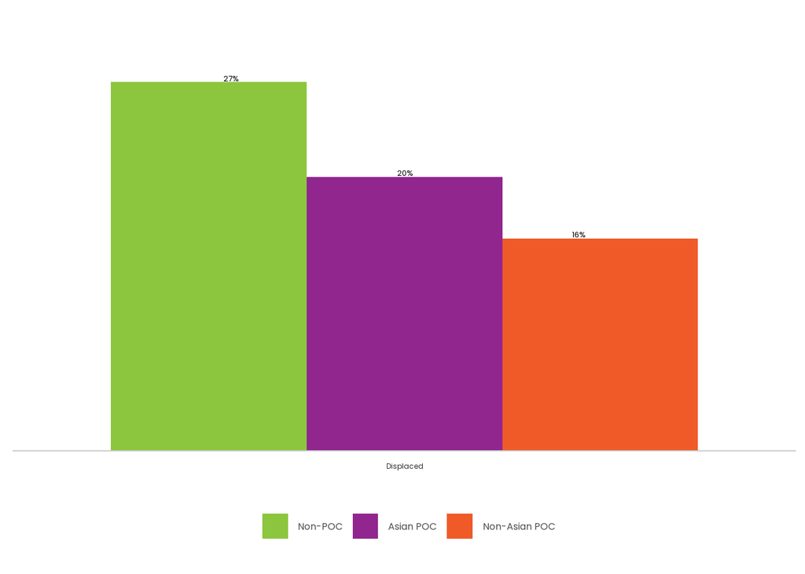

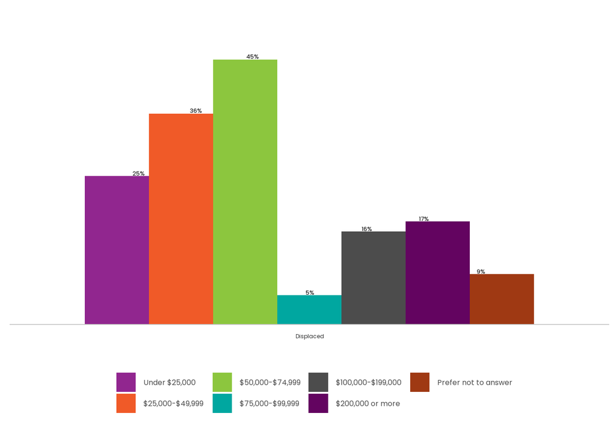

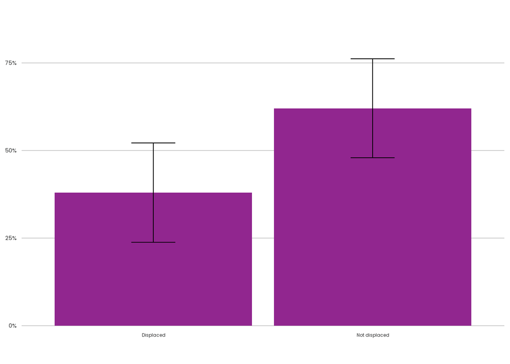

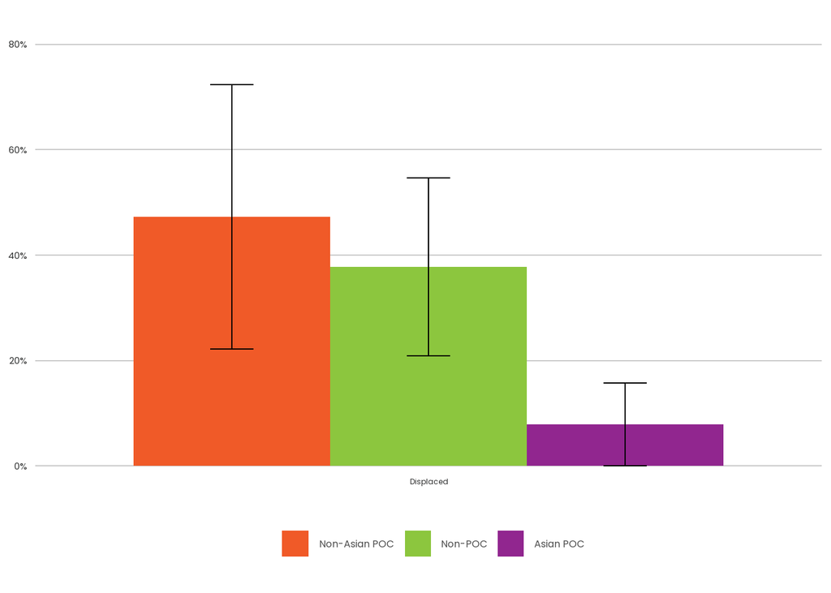

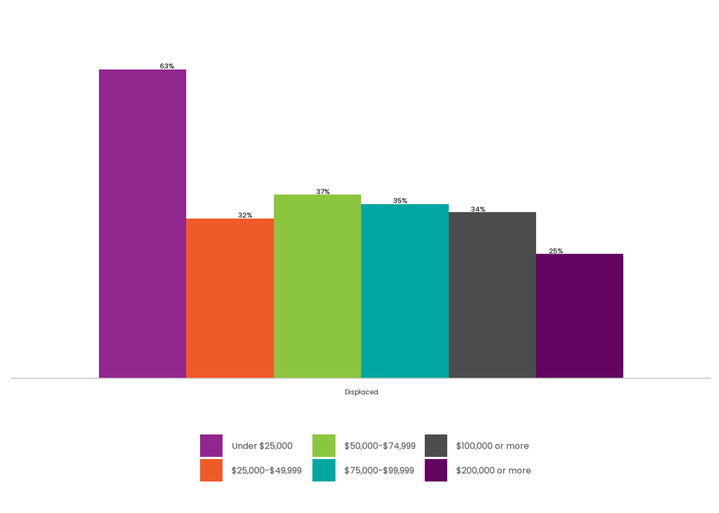

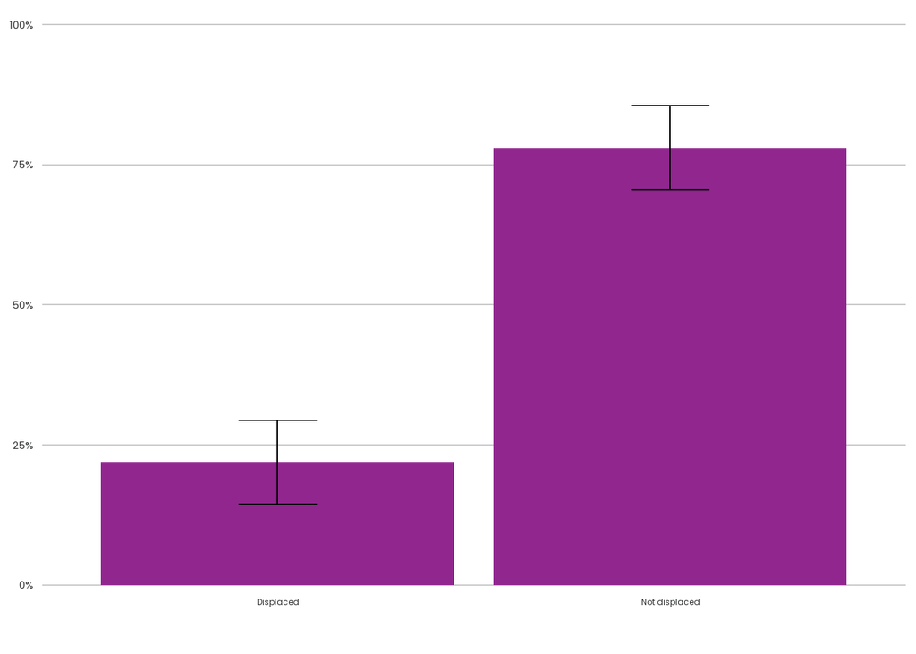

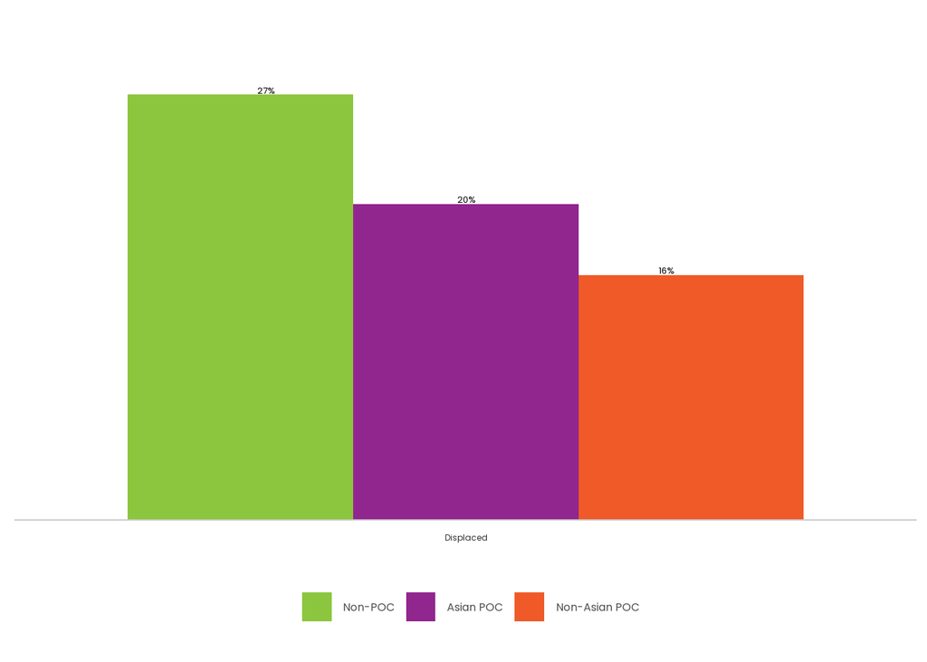

[1 more figures not shown]